# Fitbit

Rama

2022-10-28

## Latar Belakang

Studi Kasus ini menggunakan data set Bellabeat Fitbitt “(found here: https://www.kaggle.com/datasets/arashnic/fitbit).”

### Tentang Perusahaan

Urška Sršen dan Sando Mur mendirikan Bellabeat, sebuah perusahaan teknologi tinggi yang memproduksi produk pintar yang berfokus pada kesehatan. Pada tahun 2016, Bellabeat telah membuka kantor di seluruh dunia dan meluncurkan beberapa produk. Mengumpulkan data tentang aktivitas, tidur, stres, dan kesehatan reproduksi telah memungkinkan Bellabeat untuk memberdayakan wanita dengan pengetahuan tentang kesehatan dan kebiasaan mereka sendiri.

### Tiga Pertanyaan

1. Apa saja tren dalam penggunaan perangkat pintar?
2. Bagaimana tren ini dapat diterapkan pada pelanggan Bellabeat?
3. Bagaimana tren ini dapat membantu memengaruhi strategi pemasaran Bellabeat?

## Tahap Persiapan

menjalankan library yang dibutuhkan

```r
library(dplyr)
library(tidyverse)
library(lubridate)
```

```r
library(ggplot2)
library(janitor)
library(skimr)
library(scales)
```

## Proses

- total step(hour)

```r
hourly_steps <- read.csv("hourlySteps_merged.csv") %>% clean_names()
hourly_steps$activity_hour <- mdy_hms(hourly_steps$activity_hour)
```

- total sleep

```r
sleepday <- read_csv("total_sleep.csv") %>% clean_names()
```

```
## ──────────────────────────────────────────────────────── Delimiter: "," dbl
## (3): ...1, id, total_minutes_asleep date (1): sleep_Day
```

```r
sleepday <- sleepday %>% rename(date = sleep_day)%>% select(-c(x1))
```

pembersihan nama kolom dengan library janitor yaitu “clean_names()” dan menghilangkan kolom “x1” yang tidak dibutuhkan

- total step

```r
total_step <- read_csv("step_day.csv") %>% clean_names()
```

```
## ──────────────────────────────────────────────────────── Delimiter: "," dbl
## (3): ...1, id, step_day date (1): Date
```

```r
total_step <- total_step %>% select(-c(x1))
```

- calories

```r
calories <- read_csv("dailyCalories_merged.csv") %>% clean_names()
calories$activity_day <- mdy(calories$activity_day)
calories <- calories %>% rename(date=activity_day)
```

mengubah kolom “activity_day” menjadi format tanggal menggunakan mdy(month, day, year) dan mengubah nama kolom menjadi “date”

### menggabungkan semua tabel

```r
#join all tables
daily_activity <- full_join(total_step, sleepday, by= c('id', 'date'))
daily_activity <-full_join(daily_activity, calories, by=c('id','date'))
```

penggabungan tabel berdasarkan “id”, dan “date” menggunakan fungsi full join

```r
head(daily_activity)
```

```
## # A tibble: 6 × 5
##           id date       step_day total_minutes_asleep calories
##        <dbl> <date>        <dbl>                <dbl>    <dbl>
## 1 1503960366 2016-04-12    13158                  327     1985
## 2 1503960366 2016-04-13    10735                  384     1797
## 3 1503960366 2016-04-14    10460                   NA     1776
## 4 1503960366 2016-04-15     9685                  412     1745
## 5 1503960366 2016-04-16    12669                  340     1863
## 6 1503960366 2016-04-17     9705                  700     1728
```

## Analyze

```r
summary(daily_activity)
```

```
##        id                 date               step_day     total_minutes_asleep
##  Min.   :1.504e+09   Min.   :2016-04-12   Min.   :    0   Min.   : 58.0
##  1st Qu.:2.320e+09   1st Qu.:2016-04-19   1st Qu.: 3728   1st Qu.:361.0
##  Median :4.445e+09   Median :2016-04-26   Median : 7379   Median :433.0
##  Mean   :4.858e+09   Mean   :2016-04-26   Mean   : 7590   Mean   :419.5
##  3rd Qu.:6.962e+09   3rd Qu.:2016-05-04   3rd Qu.:10694   3rd Qu.:490.0
##  Max.   :8.878e+09   Max.   :2016-05-12   Max.   :36019   Max.   :796.0
##                                           NA's   :6       NA's   :530
##     calories
##  Min.   :   0
##  1st Qu.:1830
##  Median :2140
##  Mean   :2308
##  3rd Qu.:2796
##  Max.   :4900
##
```

hasil analisis cepat menampilkan analisis dari masing-masing kolom. pada kolom date, min “2016-04-12”, max “2016-05-12” yang menjelaskan data yang di analisis adalah “**12 april 2016**” sampai “**12 mei 2016**”

### rata-rata langkah kaki perhari

```r
daily_activity %>%
  group_by(id) %>%
  summarise(average_step = mean(step_day, na.rm=TRUE))
```

```
## # A tibble: 33 × 2
##            id average_step
##         <dbl>        <dbl>
##  1 1503960366       12485.
##  2 1624580081        5734.
##  3 1644430081        7264.
##  4 1844505072        2579.
##  5 1927972279         916.
##  6 2022484408       11346.
##  7 2026352035        5551.
##  8 2320127002        4711.
##  9 2347167796        9519.
## 10 2873212765        7553.
## # … with 23 more rows
```

data di atas merupakan rata-rata langkah berdasarkan id, data yang ditampilkan ada 33 baris, berarti ada 33 orang yang sedang di analisis

### aktivitas user

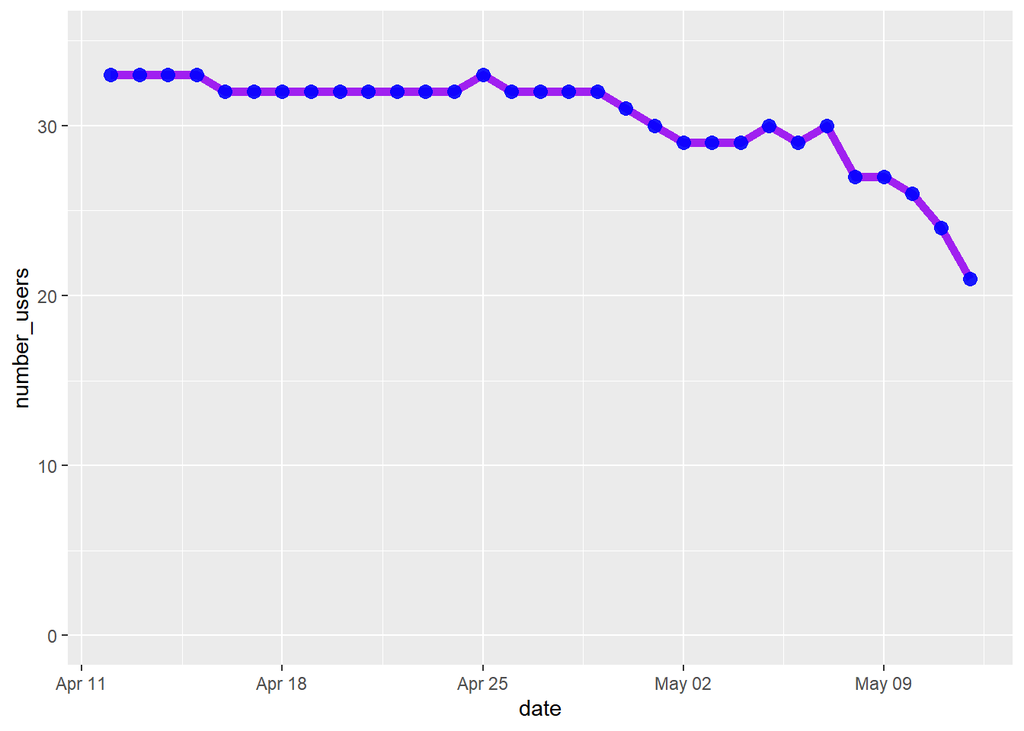

```r
daily_activity %>%
  group_by(date) %>%
  summarise(number_users = n()) %>%
  ggplot(aes(date, number_users))+
  geom_line(size = 2, col='purple')+
  geom_point(size = 3, col='blue', alpha=0.9)+
  ylim(0,35)
```

aktivitas user selama sebulan dari bulan april hingga mei, mengalami penurunan

### total tidur vs aktivitas

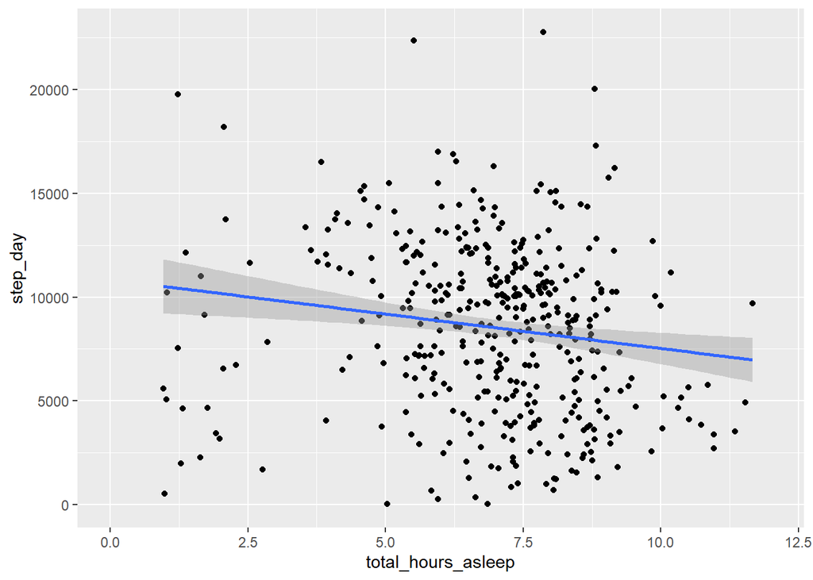

```r
daily_activity %>%
  drop_na() %>%
  summarise(total_hours_asleep = (total_minutes_asleep/60), step_day) %>%
  ggplot(aes(total_hours_asleep, step_day))+
  geom_point()+
  geom_smooth(method = lm)+
  xlim(0,12)
```

tidak ada hubungannya antara semakin lama seseorang tidur dengan semakin banyak aktivitas seseorang

### aktivitas vs kalori

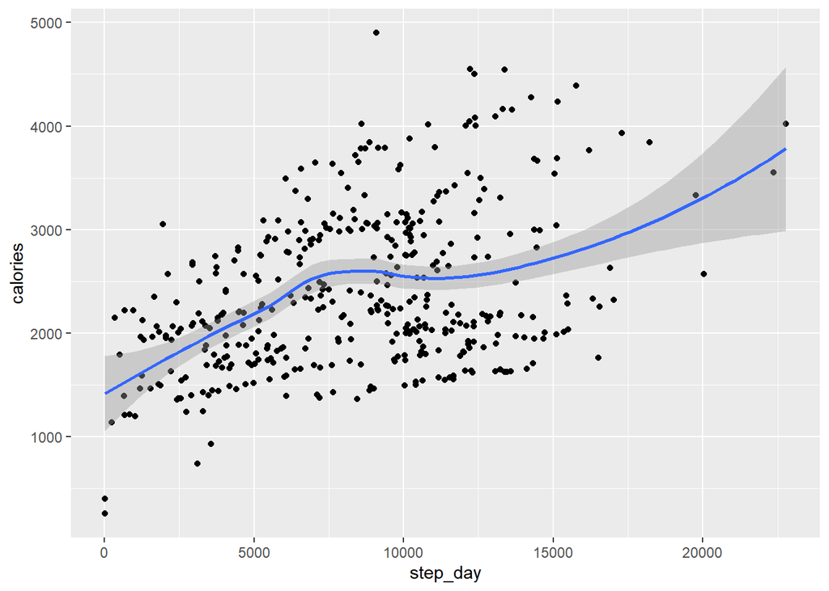

```r
daily_activity %>%
  drop_na() %>%
  group_by(id) %>%
  ggplot(aes(step_day, calories))+
  geom_point()+
  geom_smooth(method = "loess")
```

terdapat hubungan antara aktivitas dan kalori yang dikeluarkan, semakin banyak seseorang melakukan aktivitas, semakin banyak kalori yang dikeluarkan

### pola antara tidur vs aktivitas vs kalori

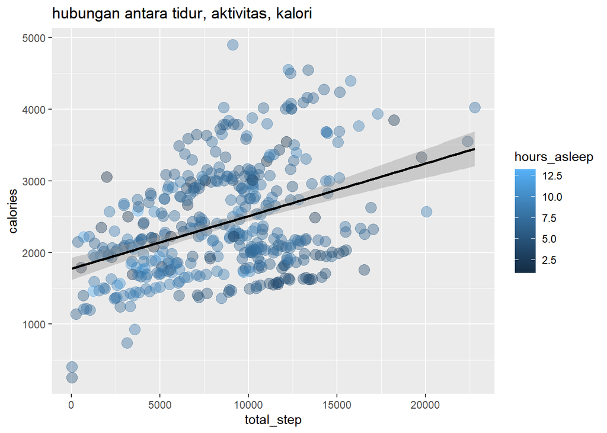

```r
daily_activity %>%  drop_na() %>%
  summarise(calories,
            hours_asleep = (total_minutes_asleep/60),
            total_step = (step_day)) %>%
  ggplot(aes(total_step, calories, col=hours_asleep))+
  geom_point(size = 4, alpha = 0.4)+
  geom_smooth(method = lm, col ='black', size = 1) +
  labs(title ='hubungan antara tidur, aktivitas, kalori')
```

### rata-rata aktivitas harian

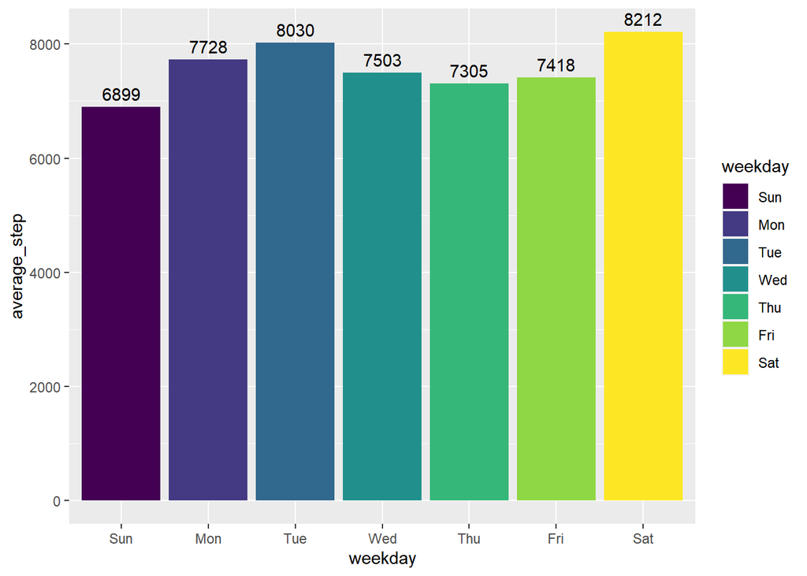

```r
daily_activity %>%
  mutate(weekday = wday(date, label = TRUE)) %>%
  group_by(weekday) %>%
  summarise(average_step = mean(step_day, na.rm=TRUE)) %>%
  arrange(weekday) %>%
  ggplot(aes(x=weekday, y=average_step, fill=weekday))+
  geom_col()+
  geom_text(aes(label=round(average_step, digits =0), vjust = -0.5))
```

rata-rata aktivitas terbanyak ada di hari sabtu dan rata-rata aktivitas terendah ada di hari minggu

### aktivitas berdasarkan jam

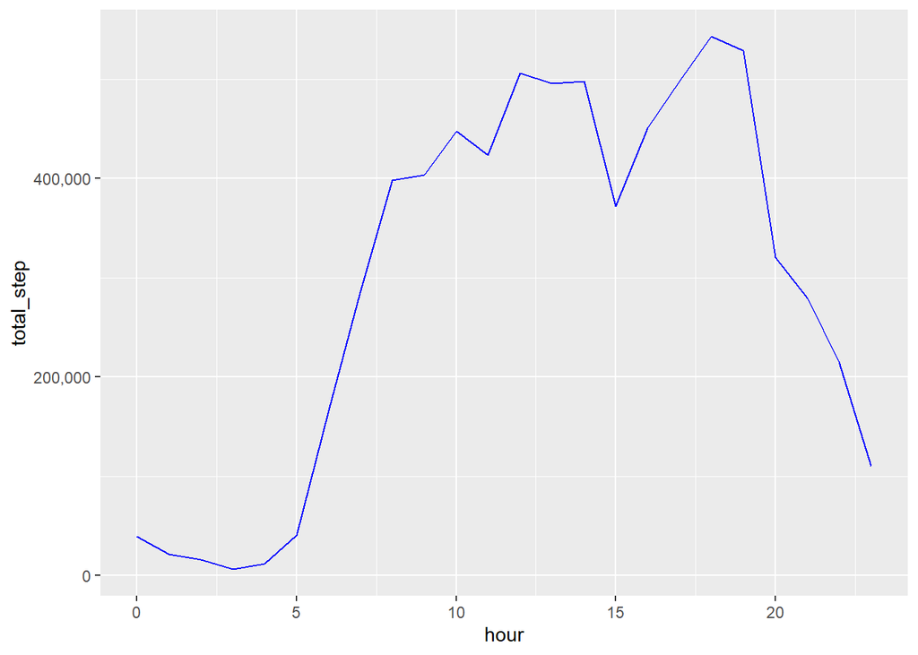

```r
hourly_steps %>%
  mutate(hour = hour(activity_hour)) %>%
  group_by(hour) %>%
  summarise (total_step = sum(step_total)) %>%
  ggplot(aes(hour, total_step))+
  geom_line(color='blue')+
  scale_y_continuous(labels=comma)
```

## Kesimpulan

- Semakin banyak seseorang melakukan aktivitas semakin tinggi kalori yang dikeluarkan. sementara semakin banyak seseorang tertidur, tidak mempengaruhi aktivitas seseorang apakah lebih aktif atau tidak
- Tren yang ditemukan, aktivitas rata-rata harian tertinggi berada di hari sabtu, pengguna lebih sering melakukan aktivitas di hari sabtu dan lebih rendah aktivitasnya di hari minggu. pengguna lebih menghabiskan waktu di dalam rumah di hari minggu
- Melihat hasil analisis dan temuan-temuan tren, dapat disimpulkan tiap aktivitas terekam di aplikasi dan berguna bagi seseorang untuk melacak aktivitas hariannya